# Reproducible Research - Project 1

#### 4. Make a histogram of the total number of steps taken each day and Calculate and report the mean and median total number of steps taken per day. Do these values differ from the estimates from the first part of the assignment? What is the impact of imputing missing data on the estimates of the total daily number of steps?

Answer) Histogram of the total number of steps taken each day:

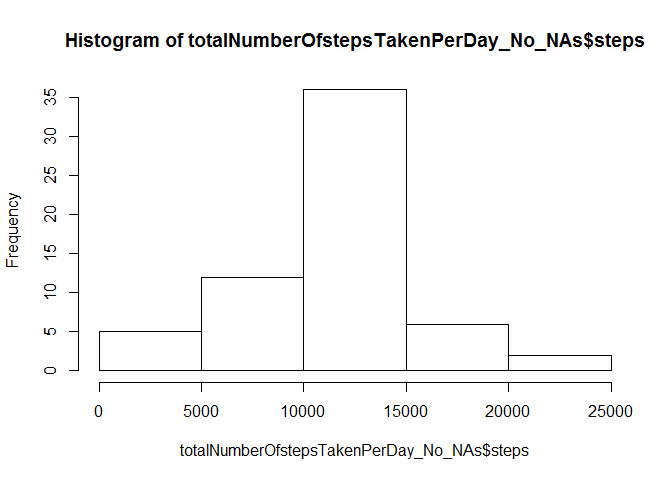

```r
totalNumberOfstepsTakenPerDay_No_NAs <- with(activities_No_NAs, aggregate(steps ~ date, FUN=sum))
    hist(totalNumberOfstepsTakenPerDay_No_NAs$steps)
```

```r
# Mean of the total number of steps taken each day.
meanTotalStepsPerDay_No_NA <- mean(totalNumberOfstepsTakenPerDay_No_NAs$steps)

# Medianof the total number of steps taken each day
medianTotalStepsPerDay_No_NA <- median(totalNumberOfstepsTakenPerDay_No_NAs$steps)
```

What is the impact of imputing missing data on the estimates of the total daily number of steps?

Answer)

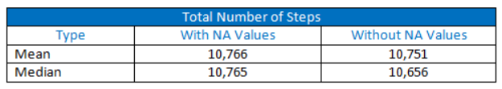

**Image of table containing both mean and median for the total number of steps with and without NA values.**

As the table depictured in the image above shows, there has not been significant changes regarding the mean and median when we compare the set with NA against the set with NO NAs.

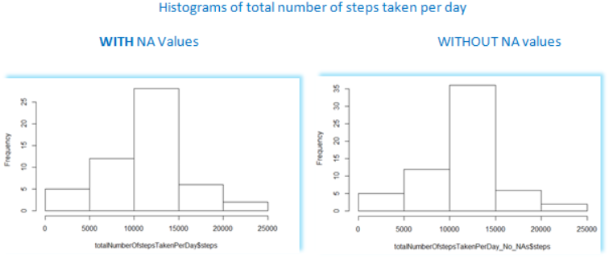

**Image of histograms side-by-side to facilitate the comparative analysis of the total number of steps taken per day with and without NA values.**

However, as the image above comparing both histograms shows, when we compare the two histograms, the introduction of values where there were NAs, caused the frequency (number of days) to increase significanlty to a little over 35 for the number of steps between 10,000 and 15,000. While in the set with NAs this same number of steps between 10000 and 15000 ocurred around 27 times or so. The conclusino is that the introduction of values into the NA fields caused the a higher number of days concentrated between 10,000 and 15,000 steps.

# Are there differences in activity patterns between weekdays and weekends?

#### 1. Create a new factor variable in the dataset with two levels - “weekday” and “weekend” indicating whether a given date is a weekday or weekend day.

```r
# Create a new data set to handle the work with weekdays and weekends.
weekSet <- activities

#Defines which days are weekdays and which ones are weekend
weekSet$dayOfWeek <- ifelse((weekdays(weekSet$date, abbreviate = FALSE) == "Saturday") | (weekdays(weekSet$date, abbreviate = FALSE) == "Sunday"), "weekend", "weekday")

# Create a new dataset with the average number of steps per interval for WEEKDAYS
avgNumberOfStepsPerInterval_Weekday <- with(subset(weekSet, dayOfWeek == "weekday"), aggregate(steps ~ interval, FUN=mean))
# add day of the week column to the newly created dataset.
avgNumberOfStepsPerInterval_Weekday$dayOfWeek <- "weekday"

#Create a new dataset with the average number of steps per interval for WEEKENDS
avgNumberOfStepsPerInterval_Weekend <- with(subset(weekSet, dayOfWeek == "weekend"), aggregate(steps ~ interval, FUN=mean))

# Add day of the week column and assign the "weekend" value to all items of this column
avgNumberOfStepsPerInterval_Weekend$dayOfWeek <- "weekend"

# Merge both sets containing weekdays and weekends.
avgNumOfStepsPerIntervalByDayofWeek <- rbind(avgNumberOfStepsPerInterval_Weekday, avgNumberOfStepsPerInterval_Weekend)
```

#### 2. Make a panel plot containing a time series plot (i.e. type = “l”) of the 5-minute interval (x-axis) and the average number of steps taken, averaged across all weekday days or weekend days (y-axis). See the README file in the GitHub repository to see an example of what this plot should look like using simulated data.

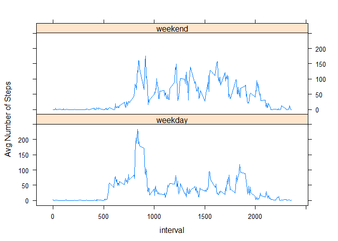

```r
# Now our data set contains all the data we need to create the time series, let's plot it.
xyplot(steps ~ interval | dayOfWeek, data = avgNumOfStepsPerIntervalByDayofWeek, layout = c(1,2), type = "l", ylab = "Avg Number of Steps" )
```